# Random walk and diffusion on network

E.B.

## Random walk motivácia

- Uvažujeme neorientovaný súvislý graf
- Aká je pravdepodobnosť prechodu z $i$ do $j$

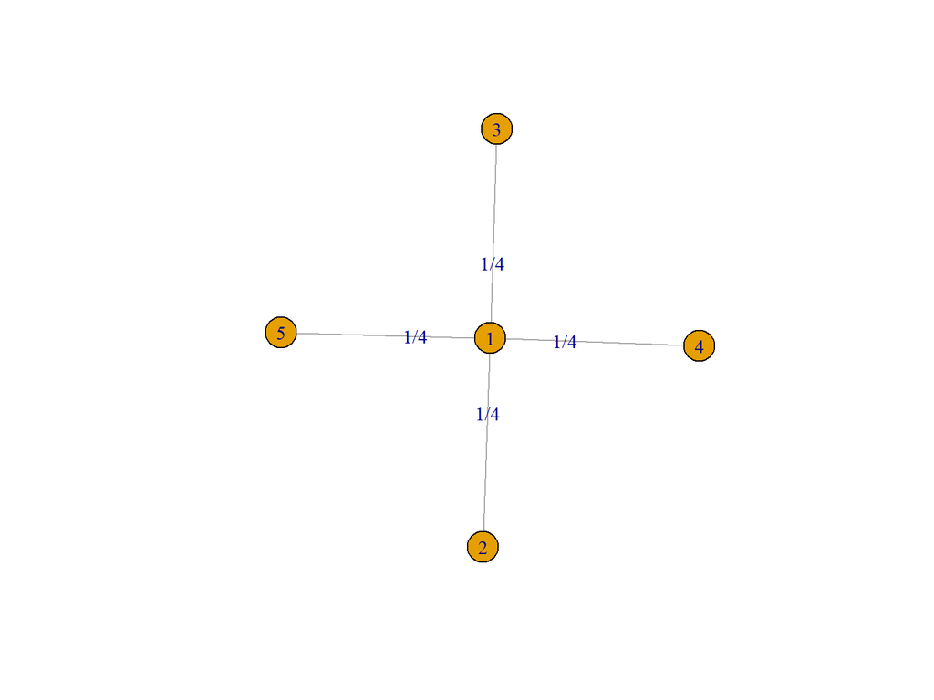

- Ako sa zmeni v i-tom kroku pravdepodobnost vo vrchole

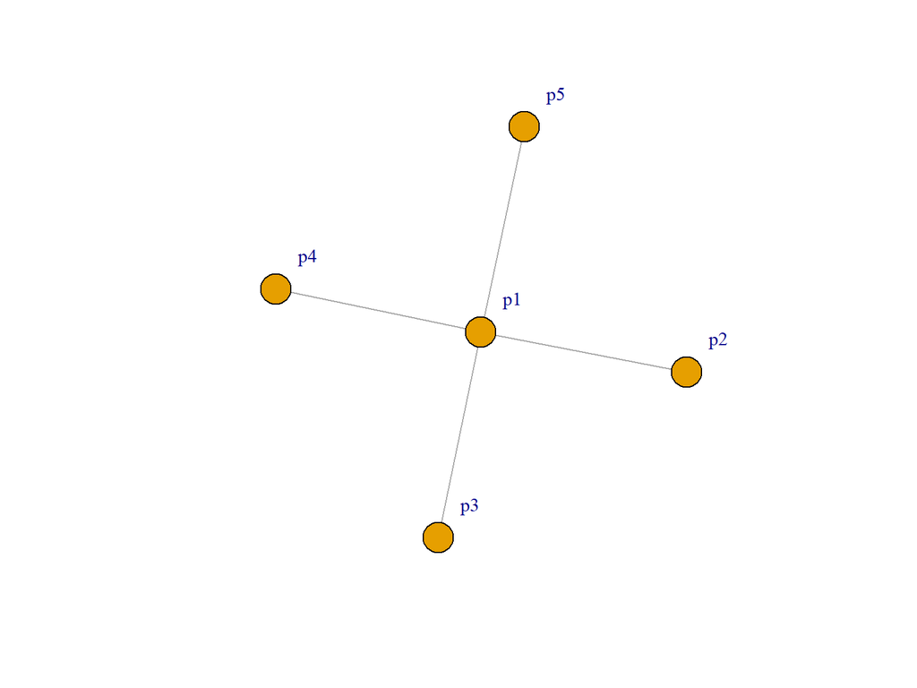

  $$p1=\frac{p2}{d(2)}+\frac{p3}{d(3)}+\frac{p4}{d(4)}+\frac{p5}{d(5)}$$

$$\pi_i^t=\sum_{j=1}^n\frac{w_{ij}}{d_j}\pi_j^{t-1}$$

**Zmenu rozdelnia** pravdepodobnosti v čase $t$ vieme vyjadriť

$\pi^t=\pi^{t-1}D^{-1}W$

Označme $P=D^{-1}W$ **maticu prechodu** kde $p_{ij}=w_{i,j}/d_i$ je pravdepodobnosť prechodu z vrcholu $v_i$ do vrcholu $v_j$. Nech $\pi^0$ je vektor **počiatočných pravdepodobnosti** výskytu vo vrcholoch grafu $\sum \pi_i^0=1$.

Pre súvislý nie bipartitný graf, **proces konverguje** ku stacionarnemu rozdeleniu

$P.\pi=\pi$ teda $1$ je vlastné číslo matice prechodu $P=D^{-1}W$.

**Stacionárne rozdelenie** vieme vyjadriť nasledovne:

$\pi_{i}=\frac{d_i}{vol(G)}$ kde $vol(G)=\sum_{i\in V}{d_i}$

[video not shown]

## Walktrap - motivácia

Využijeme tendenciu procesu zdržiavať sa v **hustých podgrafoch**.

Spočitame pravdepodobnosť prechodu z vrchola $i$ do vrchola $j$ po $t$ krokoch $P^t_{ij}$

Ak sú vrcholy v rovnakej komunite bude táto pravdepodobnosť relatívne vysoká Naopak to nemusí platiť.

Teda definujem vzdialenosť medzi $i,j$ na základe toho ako rozdielne vidia okolie.

$$r_{i,j}=\sqrt{\sum_{k=1}^n{\frac{(P_{ik}^t-P_{jk}^t)^2}{d_k}}}=\|D^{-\frac{1}{2}}P_{i\bullet}^t-D^{-\frac{1}{2}}P_{j\bullet}^t\|$$

Pravdepodobnosť že sa z komunity $C$ dostanem do vrchola $j$ je

$P_{Cj}=\frac{1}{|C|}\sum\limits_{i\in C}P_{ij}^t$ teda $P_{C\bullet}^t$

Teda vzdialenosť medzi komunitami je
$$r_{C_1C_2}=\sqrt{\sum_{k=1}^n{\frac{(P_{C_1k}^t-P_{C_2k}^t)^2}{d_k}}}$$

## algoritmus

Inšpirácia vo Wardovej aglomeratívnej metóde.

1.Začíname z jednovrcholovými komunitami $\mathcal P_0=\{\{v\},v\in V\}$ 2. Vyberieme dve susediace komunity vzhľadom na vzdialenosť a zlúčime ich 3. Aktualizujeme vzdialenosť medzi susednými komunitami

Cieľom je v každom kroku minimalizovať
$$\sigma_k=\frac{1}{n}\sum\limits_{C \in \cal P_k}\sum\limits_{i \in C}r_{iC}^2$$

Aproximujeme $greedy$ metódou. V každom kroku pre susedné komunity spočítame $\Delta\sigma(C_1,C_2)=\frac{1}{n}(\sum\limits_{i\in C_3}{r_{iC_3}^2}-\sum\limits_{i\in C_2}{r_{iC_2}^2}-\sum\limits_{i\in C_1}{r_{iC_1}^2})$ Tie z najmenšou hodnotou $\Delta\sigma$ zlúčime.

Vyhodnotenie na základe zmeny
$$\eta_k= \frac{\sigma_{k+1}-\sigma_k}{\sigma_{k}-\sigma_{k-1}}$$

[video not shown]

## Local Random walk

Verzia random walk, kde v každom kroku môže zotrvať vo vrchole s pravdepodobnosťou $\mu$ $\pi^{t+1}=\mu \pi^t + (1-\mu)\pi^{t}P$ pre $\mu=\frac{1}{2}$

Potom maticiu prechodu vieme zapísať
$$P=\frac{1}{2}(I+D^{-1}W)$$

Pracovať budeme s PageRank variantou
$$pr(\alpha,s)=\alpha s + (1-\alpha)pr(\alpha,s)P$$
**Teleportačná konštanta** $\alpha \in (0,1]$ a $s$ je preferenčný vektor

Cieľom je aproximovať $pr(\alpha,s)$

Využijeme fakt

$$pr(\alpha,s)=\alpha s + (1-\alpha)pr(\alpha,sP)$$
Teda $pr(\alpha,s)$ aproxumujeme vektorom $p$ s rezidualným vektorom $r$

## $$pr(\alpha,s)=p + pr(\alpha,r)$$

Pre vrchol $u$ defuinujeme nasledovnú operáciu $\text{push}_u(p,r)$

$p^\prime(u)=p(u)+\alpha r(u)$

Pre $v; (u,v)\in E$ modifikujem reziduá $r^\prime(v)=r(v)+(1-\alpha) r(u)/(2d(u))$

Pre ostatné $v$ nech $p^\prime(v)=p(v)$ a $r^\prime(v)=r(v)$

$$p^\prime + pr(\alpha,r^\prime)=p + pr(\alpha,r)$$

## algoritmhus

1. $p=\overrightarrow{0}, r=\chi_v$
2. Pokial $\max\limits_{u\in V}\frac{r(u)}{d(u)}>\epsilon$ zober $u$ kde $r(u)/d(u)>\epsilon$ a aplikuj $\text{push}_u$ a aktualizuj vektory $p,r$
3. vrať $p=apr(\alpha,\chi_v,r)$

## Heat kernel

- Motiácia širenie tepla v záislosti od času $t$ a $C$ difúzneho koeficientu
- Neorientovaný súvislý graf

Zemna hodnoty vo vrchole $i$ je priamoúmerná rozdielu rozdielu hodnôt voči susedom, času a difuznej konštanty teda je to možné zapísať
$$\phi_i(t+1)=\phi_i(t)+\sum_{j=1}^n{W_{ij}(\phi_j(t)-\phi_i(t))C \delta_t }$$

- Vyjadrenie zmeny hodnoty

$$\frac{\mathbf{d}\phi_i(t)}{\mathbf{d}t}=C\sum_{j=1}^n{W_{ij}(\phi_j(t)-\phi_i(t))}$$
$$\frac{\mathbf{d}\phi_i(t)}{\mathbf{d}t}=C(\sum_{j=1}^n{W_{ij}\phi_j(t)}-\sum_{j=1}^n{W_{ij}\phi_i(t)})=C(\sum_{j=1}^n{W_{ij}\phi_j(t)}-d_i\phi_i(t))=C\sum_{j=1}^n{(W_{ij}-D_{ij})\phi_j(t)}$$
$$\frac{\mathbf{d}\phi_i(t)}{\mathbf{d}t}=-C\sum_{j=1}^n{L_{ij}\phi_j(t)}$$

## Riešenie homogenného systému linearnych dif. rovníc prvého rádu.

$$\frac{\mathbf{d}\boldsymbol\phi}{\mathbf{d}t}=-C.L\boldsymbol\phi(t)$$

- Fundamentálny systém riešení homogenného systému linearných diferenciálnych rovníc s konštantnými koeficientami má tvar

$\theta_i= \mathbf{x_i}e^{\lambda_i t}$ kde $\lambda_i$ sú vlastné čísla maticového operátora a $\mathbf{x_i}$ sú prislúchajúce vlastné vektory

Všeobecné riešenie $\boldsymbol\phi(t)=\sum_i{a_i(0)\mathbf{x_i}e^{-C\lambda_i t}}$

Ako to konverguje v čase $t\rightarrow \infty$ $\boldsymbol\phi=a_1(0)\mathbf{x_1}$ Kedže sa nám objem nestraca iba sa prerozdeluje v čase platí $\boldsymbol\phi(0)=a_1(0)\frac{\mathbf e}{\sqrt N}$ teda $a_1(0)=\boldsymbol\phi(0)^\top \mathbf x_1 =\frac{1}{\sqrt N}\sum\phi_i(0)$

Teda
$$\lim_{t\rightarrow\infty}\boldsymbol\phi(t)=(\frac{1}{N}\sum\phi_i(0))\mathbf e$$

Rovnomerné rozdelenie počiatočného objemu v sieti

- Taylorov rozvoj (heat kernel)

$$\boldsymbol\phi(t)=e^{-LD^{-1}t}=e^{-t}\sum_k^\infty\frac{t^k}{k!}WD^{-1}f$$

- porovnanie s Lazy Random walk

$$\boldsymbol\pi(t)=\alpha\sum_k^\infty{(1-\alpha)^kWD^{-1}f}$$